# URI Student GPA Analysis

Mark Rogers, Audrianna Casey, Ryan Viti

6/20/2020

# Introduction

Our group decided to take a look at what factors play in college students receiving their GPA. In order to collect data, we created a Google Forms survey and shared it amongst our peers and within our campus organizations. We received a great deal of responses, and with real world data we hope to gain some insight as to what influences students receiving high, or low, GPAs, and other insight into college students as a whole. To do this, we will form different hypotheses, and perform respective analysis approaches to draw conclusions from our data. Our first question of interest is; can we create a classification tree that is able to accurately predict students’ GPA letter grade? Our second question is; can we use GPA and Hours_Work to determine if students are in a study group? And finally, can a multi-class support vector machine accurately predict students’ GPA letter grade? # Descriptive Statistics

To start, we will show the names of our variables and the head of the data set.

```
##  [1] "Gender"         "Age"            "Major"          "Double_Major"
##  [5] "Minor"          "Academic_Level" "Student_Status" "Grade"
##  [9] "GPA"            "Hours_Studying" "Study_Location" "Study_Group"
## [13] "Housing1"       "Housing2"       "Home_State"     "Hours_Sleep"
## [17] "Post_Grad"      "Campus_Org"     "Employed"       "Hours_Work"
```

```
##   Gender Age Major Double_Major Minor Academic_Level Student_Status Grade
## 1      F  22   KIN            N     0              4      Full-time    B+
## 2      F  21   PRS            Y     1              4      Full-time    B-
## 3      M  22   CSC            N     0              4      Full-time    B+
## 4      F  22   PHP            N     0              4      Full-time     B
## 5      M  21   COM            N     1              4      Full-time    B-
## 6      M  22   BUS            N     0              4      Full-time     B
##    GPA Hours_Studying Study_Location Study_Group Housing1 Housing2
## 1 3.50              4        Library       Alone      Off  Friends
## 2 2.70             10        Library       Alone      Off  Friends
## 3 3.50             10      Classroom       Group      Off  Friends
## 4 3.20             20           Home       Alone      Off  Friends
## 5 2.90              6        Library       Group      Off  Friends
## 6 3.21              5           Home       Alone      Off  Friends
##   Home_State Hours_Sleep   Post_Grad Campus_Org Employed Hours_Work
## 1         NJ         7.5 Grad school          3        Y         15
## 2         PA         6.0        Work          1        Y         10
## 3         RI         8.0        Work          1        Y         10
## 4         RI         6.0        Work          3        Y         15
## 5         RI         5.0        Work          1        Y          8
## 6         RI         9.0        Work          1        Y          6
```

Before we could get to work on our analysis, we needed to do some data processing in order to perform our analysis approaches. The first thing we did was clean up our .csv file and remove the null values and cleaned up our survey answers. For example, we received different forms of the same answer on our survey, such as “RI” and “Rhode Island” as home state, so we normalized all these by hand in Excel. The second thing we needed to do was correct the variables that have factors of only two levels, which will give us an error when making our models. We corrected this by creating dummy variables, 0s and 1s, for variables with only two factor levels. These variables were “Double_Major”, “Student_Status”, “Study_Group”, “Housing1”, and “Employed”. Below you can see the resulting tables of values for each variable after using the ifelse() function for the correction.

```
## [1] "Double_Major -> 0 = Single Major ; 1 = Double Major"
```

```
##
##  0  1
## 82  8
```

```
## [1] "Student_Status -> 0 = Full-time ; 1 = Part-time"
```

```
##
##  0  1
## 88  2
```

```
## [1] "Study_Group -> 0 = Studies alone ; 1 = Studies in a group"
```

```
##
##  0  1
## 71 19
```

```
## [1] "Housing1 -> 0 = Lives off campus ; 1 = Lives on campus"
```

```
##
##  0  1
## 47 43
```

```
## [1] "Employed -> 0 = Employed ; 1 = Unemployed"
```

```
##
##  0  1
## 46 44
```

Here we take a look at the values and value counts of our main response variable, GPA. We will also plot these values of GPA with a histogram as shown below.

```
##
##  2.2  2.3 2.51  2.6  2.7 2.76  2.8 2.83 2.85 2.87  2.9 2.94 2.95 2.99    3
##    1    3    1    1    3    1    4    1    1    1    5    1    1    1    2
## 3.01 3.02 3.06  3.1 3.12 3.19  3.2 3.21 3.27  3.3 3.34 3.35 3.38  3.4 3.41
##    1    1    1    5    1    2    5    1    1    3    1    1    1    4    1
## 3.43 3.49  3.5 3.53 3.55  3.6 3.63 3.65 3.67  3.7 3.72 3.75 3.78  3.8 3.85
##    2    2    2    1    1    6    1    1    2    2    2    1    1    3    2
## 3.87 3.89 3.91 3.94 3.95
##    1    1    1    1    1
```

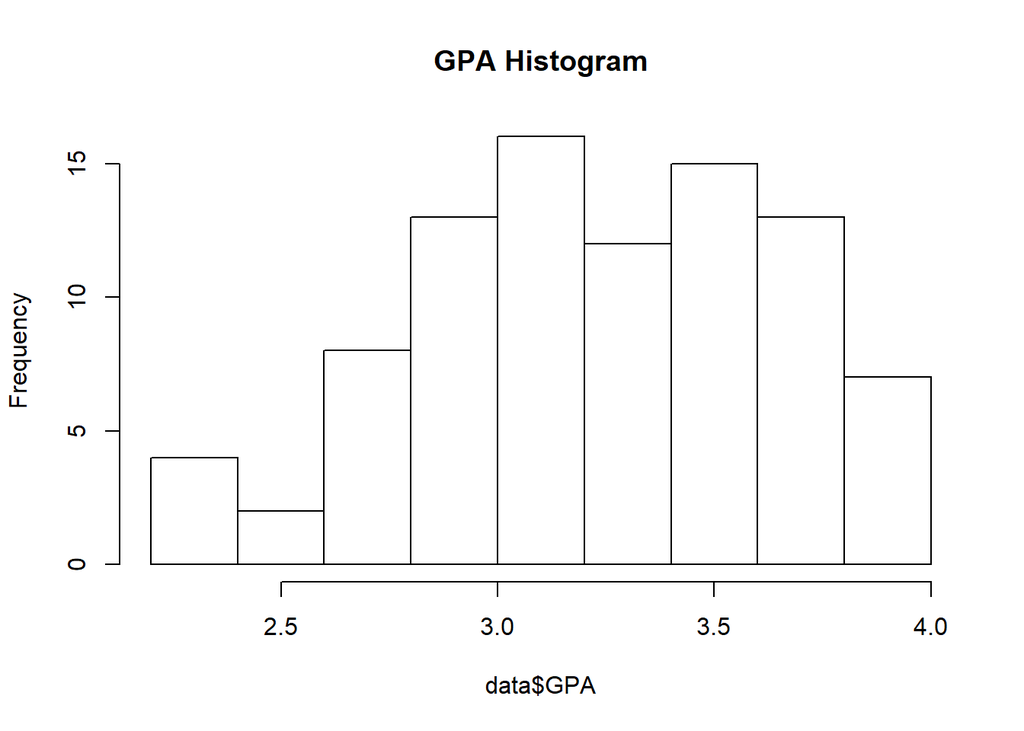

Now we output the maximum, minimum, and median of GPA.

```r
max(data$GPA)
```

```
## [1] 3.95
```

```r
min(data$GPA)
```

```
## [1] 2.2
```

```r
median(data$GPA)
```

```
## [1] 3.285
```

Also, we will look at the mean value, variance, and standard deviation of GPA.

```r
mean(data$GPA)
```

```
## [1] 3.254667
```

```r
var(data$GPA)
```

```
## [1] 0.176742
```

```r
sd(data$GPA)
```

```
## [1] 0.420407
```